# w5b: AR(P) Model

[Nao Mimoto](https://nmimoto.github.io/) - [Dept. of Statistics](http://www.uakron.edu/stat/) : [The University of Akron](http://www.uakron.edu)

[Class Web Page](https://nmimoto.github.io/477/)

## 1. Ex: Fit Dow Jones 1972 with AR(3)

```r
  # read in daily Dow Jones data from my website
  D  <- read.csv("https://nmimoto.github.io/datasets/dowj.csv")
  head(D)                             # see only first 6 lines
```

```
##     dowj
## 1 110.94
## 2 110.69
## 3 110.43
## 4 110.56
## 5 110.75
## 6 110.84
```

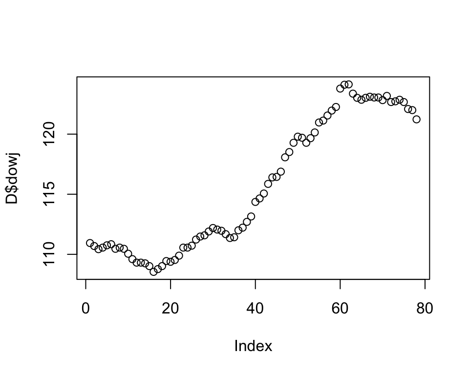

```r
  plot(D$dowj)
```

```r
  is.ts(D)                            # is it TS object  -> no
```

```
## [1] FALSE
```

```r
  D1 <- ts(D$dowj, start=c(1971,1), freq=12)   # turn the data into TS object
  head(D)
```

```
##     dowj
## 1 110.94
## 2 110.69
## 3 110.43
## 4 110.56
## 5 110.75
## 6 110.84
```

```r
  is.ts(D1)                           # D1 is TS object
```

```
## [1] TRUE
```

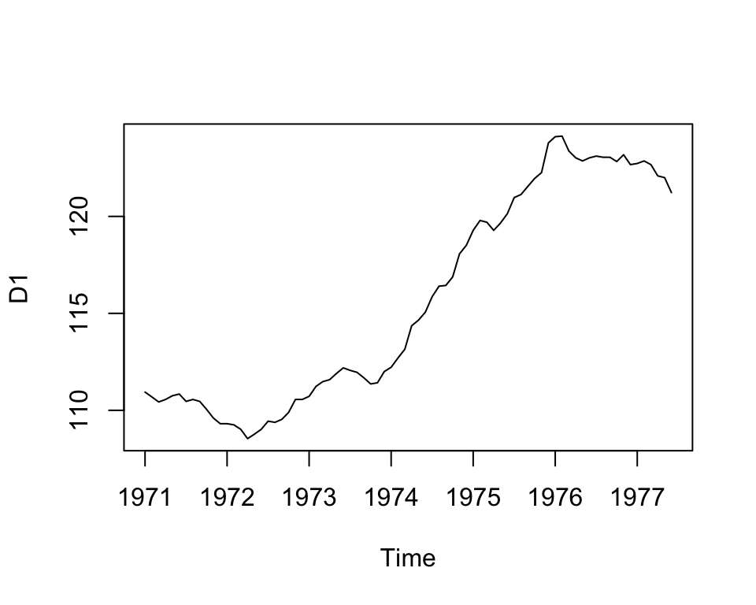

```r
  plot(D1)
```

```r
  Y1 <- diff(log(D1))                  # Take log-difference log(X_{t}) - log(X_{t-1})
  head(Y1)                             # see first 6 lines
```

```
##                Feb           Mar           Apr           May           Jun
## 1971 -0.0022560132 -0.0023516653  0.0011765240  0.0017170489  0.0008123111
##                Jul
## 1971 -0.0034342555
```

```r
  Y <- Y1[-1]                          # remove the first observation because it's NA
  head(Y)
```

```
## [1] -0.0023516653  0.0011765240  0.0017170489  0.0008123111 -0.0034342555
## [6]  0.0009048955
```

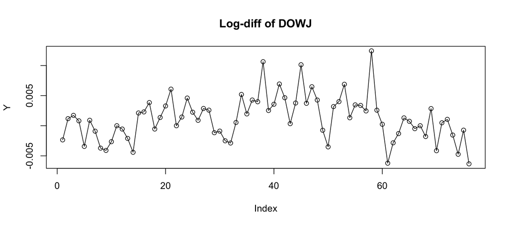

```r
  plot(Y, type='o', main="Log-diff of DOWJ")
```

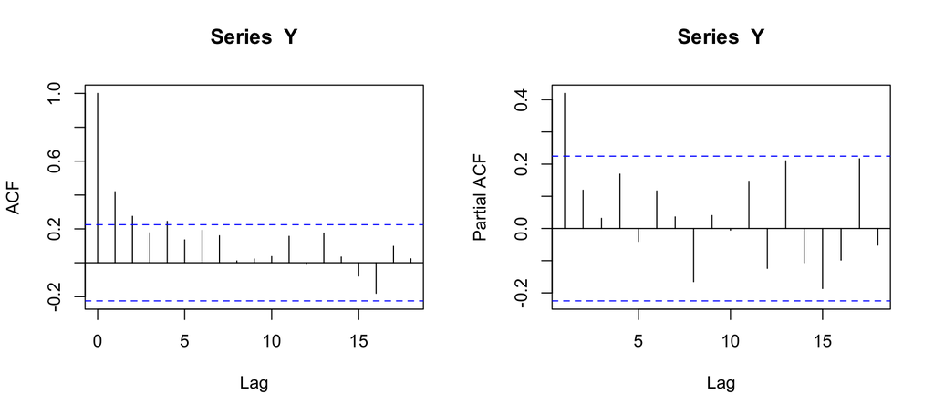

```r
  layout(matrix(1:2, 1, 2))           # make next two plot side by side (you don't have to do this)
  acf(Y)                              # Sample ACF
  pacf(Y)                             # Sample Partial ACF (see below)
```

```r
  layout(1)                           # turn it back to 1 plot layout

  library(forecast)                   # install.packages("forecast")

  Fit1 <- Arima(Y, order=c(3,0,0))    # fit AR(3) to Y
  Fit1                                # see the result of fit
```

```
## Series: Y
## ARIMA(3,0,0) with non-zero mean
##
## Coefficients:
##          ar1     ar2     ar3   mean
##       0.3888  0.0996  0.0502  1e-03
## s.e.  0.1172  0.1256  0.1183  8e-04
##
## sigma^2 estimated as 1.102e-05:  log likelihood=327.89
## AIC=-645.79   AICc=-644.93   BIC=-634.13
```

```r
  str(Fit1)  # see what else is in Fit1
```

```
## List of 18
##  $ coef     : Named num [1:4] 0.38878 0.09959 0.05019 0.00102
##   ..- attr(*, "names")= chr [1:4] "ar1" "ar2" "ar3" "intercept"
##  $ sigma2   : num 1.1e-05
##  $ var.coef : num [1:4, 1:4] 1.37e-02 -5.59e-03 -1.16e-03 -4.24e-06 -5.59e-03 ...
##   ..- attr(*, "dimnames")=List of 2
##   .. ..$ : chr [1:4] "ar1" "ar2" "ar3" "intercept"
##   .. ..$ : chr [1:4] "ar1" "ar2" "ar3" "intercept"
##  $ mask     : logi [1:4] TRUE TRUE TRUE TRUE
##  $ loglik   : num 328
##  $ aic      : num -646
##  $ arma     : int [1:7] 3 0 0 0 1 0 0
##  $ residuals: Time-Series [1:76] from 1 to 76: -0.002987 0.001655 0.001037 -0.000324 -0.00445 ...
##  $ call     : language Arima(y = Y, order = c(3, 0, 0))
##  $ series   : chr "Y"
##  $ code     : int 0
##  $ n.cond   : int 0
##  $ nobs     : int 76
##  $ model    :List of 10
##   ..$ phi  : num [1:3] 0.3888 0.0996 0.0502
##   ..$ theta: num [1:2] 0 0
##   ..$ Delta: num(0)
##   ..$ Z    : num [1:3] 1 0 0
##   ..$ a    : num [1:3] -7.35e-03 -4.64e-04 -8.81e-05
##   ..$ P    : num [1:3, 1:3] 0 0 0 0 0 0 0 0 0
##   ..$ T    : num [1:3, 1:3] 0.3888 0.0996 0.0502 1 0 ...
##   ..$ V    : num [1:3, 1:3] 1 0 0 0 0 0 0 0 0
##   ..$ h    : num 0
##   ..$ Pn   : num [1:3, 1:3] 1 0 0 0 0 0 0 0 0
##  $ aicc     : num -645
##  $ bic      : num -634
##  $ x        : num [1:76] -0.002352 0.001177 0.001717 0.000812 -0.003434 ...
##  $ fitted   : Time-Series [1:76] from 1 to 76: 0.000635 -0.000479 0.00068 0.001136 0.001016 ...
##  - attr(*, "class")= chr [1:3] "forecast_ARIMA" "ARIMA" "Arima"
```

```r
  e.hat <- Fit1$resid                      # extract residuals after the fit
  is.ts(e.hat)
```

```
## [1] TRUE
```

```r
  head(e.hat)
```

```
## Time Series:
## Start = 1
## End = 6
## Frequency = 1
## [1] -0.002986831  0.001655083  0.001037482 -0.000324162 -0.004449901  0.001603206
```

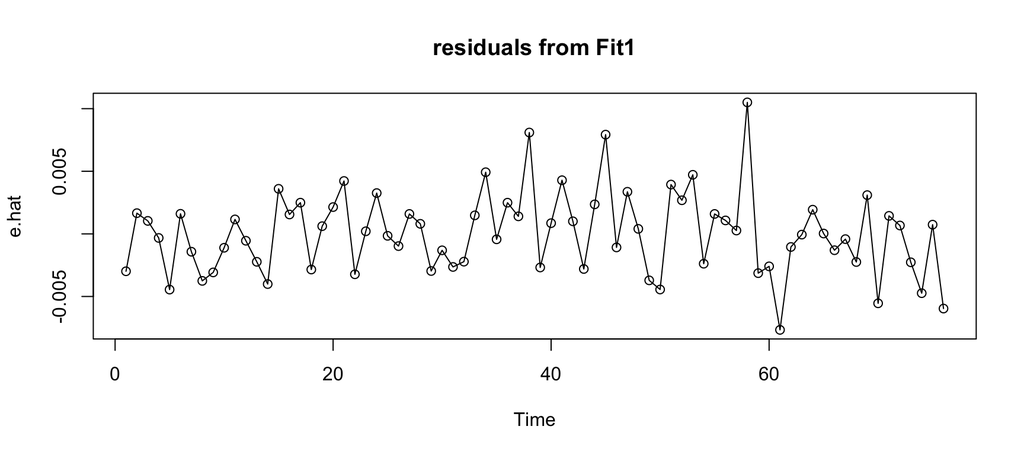

```r
  plot(e.hat, type="o", main="residuals from Fit1")  # plot residuals
```

### Notes:

In this example, $D_t$ was the original daily colse price of Dow Jones from 1972. Then the series was transformed to log-difference,
$$Y_t = \ln(X_t)-\ln(X_{t-1} = \ln(X_t/X_{t-1})$$
which represents apprximate percentage of daily gain/loss of any financial data.

To $Y_t$, AR(3) was fit. That means $Y_t$ was modeled by the model:
$$Y_t = \phi_1 Y_{t-1} + \phi_2 Y_{t-2} + \phi_3 Y_{t-3} + e_t
\hspace10mm \mbox{ where } e_t \sim WN(0,\sigma).$$
All parameter estimates, $\hat \phi_1, \hat \phi_2, \hat \phi_3, \hat \sigma$, were calculated.

### Questions:

Did $Y_t$ look stationary? Was the mean significantly different from 0?

How did we decide on the value of $p$ to fit? **( Order Selection )**

```
+ In this case, $p=3$ was chosen, but there's better way to choose $p$.
```

What estimator was used for $\phi_1, \phi_2, \phi_3$? What is the accuracy of the estimator, and what does it say about the choice of $p$? **( Paramete Estimation )**

```
+ Test for the parameter significance using the Standrad Error of the estimators.
  Can you reject he null hypothesis that $\phi_i=0$?
```

How was the residual calculated? What does it say about how the model fits the data? **( Residual Analysis )**

[output not shown]

Let’s skip the order selection for now, and start with parameter estimation.

## 2. Parameter Estimation w Yule-Walker

### Yule-Walker Equation

We start with AR(p) equation. Let $p=3$ for now,
$$X_t - \phi_1 X_{t-1} - \phi_2 X_{t-2} - \phi_3 X_{t-3} \hspace3mm = \hspace3mm e_t.$$
We multiply both sides by $X_t$, and take expectation.
$$E\Big( X_t \, [X_t - \phi_1 X_{t-1} - \phi_2 X_{t-2} - \phi_3 X_{t-3}] \Big)
\hspace3mm = \hspace3mm E\Big( X_t \, [ e_t ]\Big).$$

Recall the formula for covariance,
$$\mbox{Cov}(X_t,X_{t-1}) = E(X_t \, X_{t-1}) - E(X_t)E(X_{t-1}).$$
So if $E(X_t)=0$, then
$$\gamma(1) = E(X_t \, X_{t-1}).$$

Then the equation
$$E\Big( X_t \, [X_t - \phi_1 X_{t-1} - \phi_2 X_{t-2} - \phi_3 X_{t-3}] \Big)
\hspace3mm = \hspace3mm E\Big( X_t \, [ e_t ]\Big).$$
can be written as
$$\gamma(0) - \phi_1 \gamma(1) - \phi_2 \gamma(2) - \phi_3 \gamma(3) = \sigma^2
\hspace30mm \mbox{ (Eqn 1) }$$

Now repeat the process starting with $X_{t+1}$ instead of $X_t$,
$$X_{t+1} - \phi_1 X_{t} - \phi_2 X_{t-1} - \phi_3 X_{t-2} \hspace3mm = \hspace3mm e_{t+1}$$
then we would have gotten
$$E\Big( X_{t} \, [X_{t+1} - \phi_1 X_{t} - \phi_2 X_{t-1} - \phi_3 X_{t-2}] \Big)
\hspace3mm = \hspace3mm E\Big( X_t \, [ e_{t+1} ]\Big).$$
$$\gamma(1) - \phi_1 \gamma(0) - \phi_2 \gamma(1) - \phi_3 \gamma(2) \hspace3mm = \hspace3mm 0.
\hspace30mm \mbox{ (Eqn 2) }$$

If we use the original AR(3) equation for $X_{t+2}$ instead of for $X_t$, we would get
$$E\Big( X_{t} \, [X_{t+2} - \phi_1 X_{t+1} - \phi_2 X_{t} - \phi_3 X_{t-1}] \Big)
\hspace3mm = \hspace3mm E\Big( X_t \, [ e_{t+2} ]\Big).$$
$$\gamma(2) - \phi_1 \gamma(1) - \phi_2 \gamma(0) - \phi_3 \gamma(1) \hspace3mm = \hspace3mm 0.
\hspace30mm \mbox{ (Eqn 2) }$$

Repeat it one more time, and we get equations,
$$\gamma(0) - \phi_1 \gamma(1) - \phi_2 \gamma(2) - \phi_3 \gamma(3) \hspace3mm = \hspace3mm \sigma^2\\ \\
\gamma(1) - \phi_1 \gamma(0) - \phi_2 \gamma(1) - \phi_3 \gamma(2) \hspace3mm = \hspace3mm 0\\
\gamma(2) - \phi_1 \gamma(1) - \phi_2 \gamma(0) - \phi_3 \gamma(1) \hspace3mm = \hspace3mm 0\\
\gamma(3) - \phi_1 \gamma(2) - \phi_2 \gamma(1) - \phi_3 \gamma(0) \hspace3mm = \hspace3mm 0.$$

We set aside the first equation, and re-write the rest of equations
$$\gamma(1) - \phi_1 \gamma(0) - \phi_2 \gamma(1) - \phi_3 \gamma(2) \hspace3mm = \hspace3mm 0\\
\gamma(2) - \phi_1 \gamma(1) - \phi_2 \gamma(0) - \phi_3 \gamma(1) \hspace3mm = \hspace3mm 0\\
\gamma(3) - \phi_1 \gamma(2) - \phi_2 \gamma(1) - \phi_3 \gamma(0) \hspace3mm = \hspace3mm 0$$
as
$$\phi_1 \gamma(0) + \phi_2 \gamma(1) + \phi_3 \gamma(2) \hspace3mm = \hspace3mm \gamma(1) \\
\phi_1 \gamma(1) + \phi_2 \gamma(0) + \phi_3 \gamma(1) \hspace3mm = \hspace3mm \gamma(2) \\
\phi_1 \gamma(2) + \phi_2 \gamma(1) + \phi_3 \gamma(0) \hspace3mm = \hspace3mm \gamma(3).$$
Which can be put in a matrix form as
$$\left[ \begin{array}{cccc}
\gamma(0) & \gamma(1) & \gamma(2) \\
\gamma(1) & \gamma(0) & \gamma(1) \\
\gamma(2) & \gamma(1) & \gamma(0) \\
\end{array} \right]
\hspace2mm
\left[ \begin{array}{c}
\phi_1 \\ \phi_2 \\ \phi_3\\
\end{array}\right]
=
\left[ \begin{array}{c}
\gamma(1) \\ \gamma(2) \\ \gamma(3) \\
\end{array} \right].$$

We still have the first equation,
$$\gamma(0) - \phi_1 \gamma(1) - \phi_2 \gamma(2) - \phi_3 \gamma(3) \hspace3mm = \hspace3mm \sigma^2.$$

These two equations are called **Yule-Walker Equations**.

### Yule-Walker Estimators for AR(p)

For AP(3), Y-W equations are:
$$\gamma(0) - \phi_1 \gamma(1) - \phi_2 \gamma(2) - \phi_3 \gamma(3) \hspace3mm = \hspace3mm \sigma^2$$
$$\left[ \begin{array}{cccc}
\gamma(0) & \gamma(1) & \gamma(2) \\
\gamma(1) & \gamma(0) & \gamma(1) \\
\gamma(2) & \gamma(1) & \gamma(0) \\
\end{array} \right]
\hspace2mm
\left[ \begin{array}{c}
\phi_1 \\ \phi_2 \\ \phi_3\\
\end{array}\right]
\hspace3mm = \hspace3mm
\left[ \begin{array}{c}
\gamma(1) \\ \gamma(2) \\ \gamma(3) \\
\end{array} \right].$$
Which can be soved for $\phi_i$,
$$\left[ \begin{array}{c}
\phi_1 \\ \phi_2 \\ \phi_3\\
\end{array}\right]
\hspace3mm = \hspace3mm
\left[ \begin{array}{cccc}
\gamma(0) & \gamma(1) & \gamma(2) \\
\gamma(1) & \gamma(0) & \gamma(1) \\
\gamma(2) & \gamma(1) & \gamma(0) \\
\end{array} \right] ^{-1}
\hspace2mm
\left[ \begin{array}{c}
\gamma(1) \\ \gamma(2) \\ \gamma(3) \\
\end{array} \right].$$

We can use Y-W equasion backwards with sample ACVF to estimate parameters.
$$\left[ \begin{array}{c}
\hat \phi_1 \\ \hat \phi_2 \\ \hat \phi_3\\
\end{array}\right]
\hspace3mm = \hspace3mm
\left[ \begin{array}{cccc}
\hat \gamma(0) & \hat \gamma(1) & \hat \gamma(2) \\
\hat \gamma(1) & \hat \gamma(0) & \hat \gamma(1) \\
\hat \gamma(2) & \hat \gamma(1) & \hat \gamma(0) \\
\end{array} \right]^{-1}
\hspace2mm
\left[ \begin{array}{c}
\hat \gamma(1) \\ \hat \gamma(2) \\ \hat \gamma(3) \\
\end{array} \right]. \\ \\
\mathbf{\hat \phi_3}
\hspace3mm = \hspace3mm
\mathbf{ \hat \Gamma^{-1}_3} \hspace2mm \mathbf{\hat \gamma_3}$$

$$\hat \sigma^2 \hspace3mm = \hspace3mm \hat \gamma(0) - \hat \phi_1 \hat \gamma(1) - \hat \phi_2 \hat \gamma(2) - \hat \phi_3 \hat \gamma(3)$$

### Ex: Y-W Estimator with Simulated Data

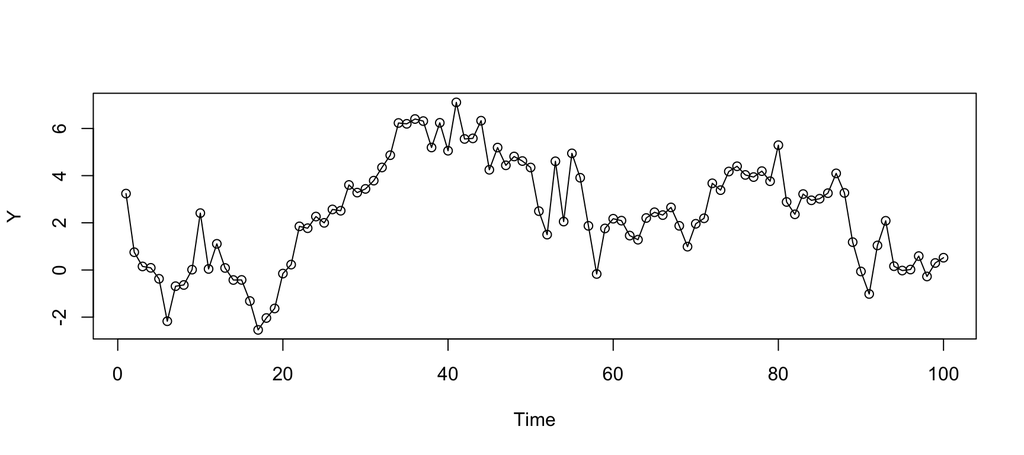

```r
  Y <- arima.sim(list(ar = c(.6, .3) ), 100 )

  plot(Y, type="o")
```

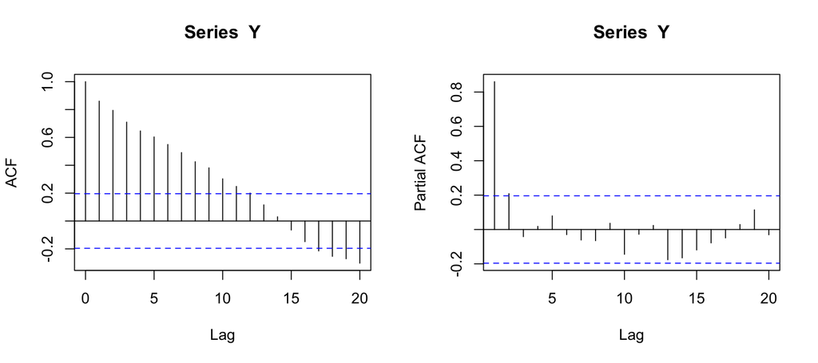

```r
  layout(matrix(1:2, 1,2))  # 2 plots side by side
  acf(Y)
  pacf(Y)
```

```r
  layout(1)                 # reset the layout

  Fit2 <- ar(Y, aic=FALSE, order.max=3)             # fits AR(3) by Y-W method(default)
  #Fit2 <- ar(Y, aic=F, order.max=2, method="mle")  # fits AR(2) by MLE
  ?ar                                               # opens help page of function ar()
```

### Large sample property of Yule-Walker Estimator

$\sqrt{n}(\hat \phi_p - \phi_p)$ is approximately multivariate normal, $N_p(0, \sigma^2 \mathbf \Gamma^{-1}/n)$, when $n$ is large. (B-D p141)

That means 95% confidence interval for $\phi_{j}$ is
$$\hat \phi_{j} \pm 1.96 \sqrt{ \frac{\hat{\sigma}^2 \, \hat{\Gamma}^{-1}_{jj}}{n} }$$
where $\hat{\Gamma}^{-1}_{jj}$ be $j$th diagnal element of the inverse matrix $\mathbf{\hat{\Gamma}^{-1}}$.

If you use **ar()** function, **$asy.var.coef** of an output is same as $\sigma^2 \mathbf \Gamma^{-1}/n$.

### Ex: Testing AR parameters for significance

```r
  Y    <- arima.sim(list(ar = c(.6, .3) ), 100 ) # Simulate AR(2)
  Fit2 <- ar(Y, aic=FALSE, order.max=3)          # fit AR(3) by Y-W(default)
  Fit2
```

```
##
## Call:
## ar(x = Y, aic = FALSE, order.max = 3)
##
## Coefficients:
##      1       2       3
## 0.6580  0.2305  0.0034
##
## Order selected 3  sigma^2 estimated as  1.112
```

```r
  str(Fit2)                               # see what's inside
```

```
## List of 15
##  $ order       : num 3
##  $ ar          : num [1:3] 0.65796 0.23047 0.00338
##  $ var.pred    : num 1.11
##  $ x.mean      : num 0.178
##  $ aic         : Named num [1:4] 135.15 3.57 0 2
##   ..- attr(*, "names")= chr [1:4] "0" "1" "2" "3"
##  $ n.used      : int 100
##  $ n.obs       : int 100
##  $ order.max   : num 3
##  $ partialacf  : num [1:3, 1, 1] 0.85852 0.2327 0.00338
##  $ resid       : Time-Series [1:100] from 1 to 100: NA NA NA 0.605 -0.475 ...
##  $ method      : chr "Yule-Walker"
##  $ series      : chr "Y"
##  $ frequency   : num 1
##  $ call        : language ar(x = Y, aic = FALSE, order.max = 3)
##  $ asy.var.coef: num [1:3, 1:3] 0.01042 -0.00686 -0.00242 -0.00686 0.01437 ...
##  - attr(*, "class")= chr "ar"
```

```r
  phi.hat    <- Fit2$ar                   # phi-hats
  sigSq.hat  <- Fit2$var.pred             # sig^2 hat
  Fit2$asy.var.coef                       # Variance of phi-hats
```

```
##              [,1]         [,2]         [,3]
## [1,]  0.010416548 -0.006861833 -0.002423911
## [2,] -0.006861833  0.014372696 -0.006861833
## [3,] -0.002423911 -0.006861833  0.010416548
```

```r
  phiSE <- sqrt(Fit2$asy.var.coef)        # take sqrt() element wise.  just look at the diagnal elements
  phi.hat                                 # check if phi hats are significant
```

```
## [1] 0.65795750 0.23047309 0.00337767
```

```r
  phiSE
```

```
##           [,1]      [,2]      [,3]
## [1,] 0.1020615       NaN       NaN
## [2,]       NaN 0.1198862       NaN
## [3,]       NaN       NaN 0.1020615
```

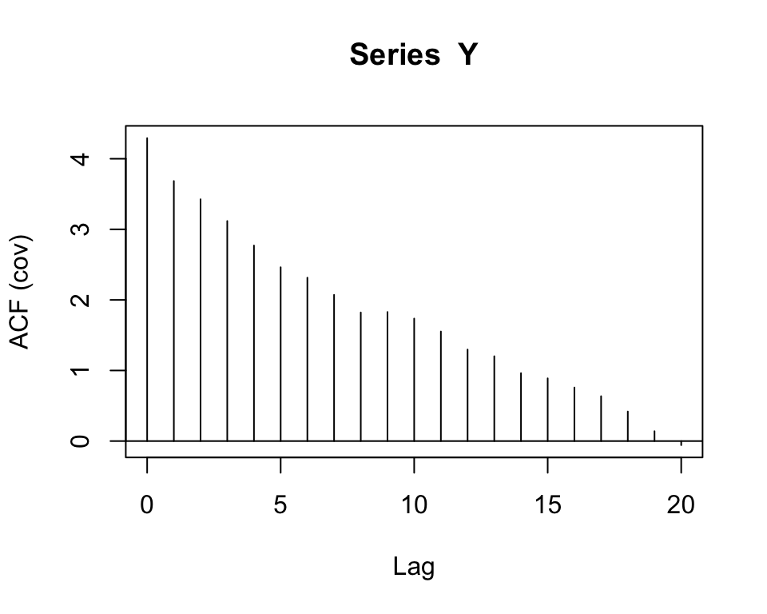

```r
  #- If you want to calculare asy.var.coef by hand -
  A <- acf(Y, type="covariance")$acf
```

```r
  G <- matrix(A[c(1,2,2,1)], 2,2)
  sigSq.hat * solve(G) / 100                  #- compare to asy.var.coef
```

```
##              [,1]         [,2]
## [1,]  0.009852508 -0.008458568
## [2,] -0.008458568  0.009852508
```

## 3. Partial ACF

Recall the Yule-Walker Equation,
$$\left[ \begin{array}{c}
\phi_1 \\ \phi_2 \\ \phi_3\\
\end{array}\right]
\hspace3mm = \hspace3mm
\left[ \begin{array}{cccc}
\gamma(0) & \gamma(1) & \gamma(2) \\
\gamma(1) & \gamma(0) & \gamma(1) \\
\gamma(2) & \gamma(1) & \gamma(0) \\
\end{array} \right]^{-1}
\hspace2mm
\left[ \begin{array}{c}
\gamma(1) \\ \gamma(2) \\ \gamma(3) \\
\end{array} \right].$$
$$\mathbf{\phi_3} \hspace3mm = \hspace3mm
\mathbf{ \Gamma^{-1}_3} \hspace2mm \mathbf{\gamma_3}$$
Note that this equation, can be extended to more than 3 parameters, even though we only have 3 $\phi$’s.

For example, if we use $\mathbf{\Gamma_5}$, then
$$\left[ \begin{array}{c}
\phi_1 \\ \phi_2 \\ \phi_3\\ 0\\ 0\\
\end{array}\right]
\hspace3mm = \hspace3mm
\left[ \begin{array}{ccccc}
\gamma(0) & \gamma(1) &\gamma(2) & \gamma(3) & \gamma(4) \\
\gamma(1) & \gamma(0) &\gamma(1) & \gamma(0) & \gamma(3) \\
\gamma(2) & \gamma(1) &\gamma(0) & \gamma(1) & \gamma(2) \\
\gamma(3) & \gamma(2) &\gamma(1) & \gamma(0) & \gamma(1) \\
\gamma(4) & \gamma(3) &\gamma(2) & \gamma(1) & \gamma(0) \\
\end{array} \right]^{-1}
\hspace2mm
\left[ \begin{array}{c}
\gamma(1) \\ \gamma(2) \\ \gamma(3) \\ \gamma(4) \\ \gamma(5) \\
\end{array} \right] \\$$
$$\mathbf{\phi_5} \hspace3mm = \hspace3mm
\mathbf{ \Gamma^{-1}_5} \hspace2mm \mathbf{\gamma_5}.$$

### PACF

Partial ACF of lag $h$ is defined as last element of vector
$$\mathbf{\phi_h} \hspace3mm = \hspace3mm
\mathbf{ \Gamma^{-1}_h} \hspace2mm \mathbf{\gamma_h}.$$
For AR(p),
$$\left\{
\begin{array}{ll}
\alpha(0) = 1 \\
\alpha(h) = \phi_h & \mbox{ if } 1 < h \leq p \\
\alpha(h) = 0 & \mbox{ if } p < h \\
\end{array} \right.$$

PACF of AR($p$) cuts off after lag $p$.

### Sample PACF

Sample version of PACF of lag $h$ is the last element of
$$\mathbf{\hat \phi_h} \hspace3mm = \hspace3mm
\mathbf{ \hat \Gamma^{-1}_h} \hspace2mm \mathbf{\hat \gamma_h}.$$
For AR(p),
$$\left\{
\begin{array}{ll}
\alpha(0) = 1 \\
\alpha(h) = \phi_h & \mbox{ if } 1 < h \leq p \\
\alpha(h) = 0 & \mbox{ if } p < h \\
\end{array} \right.$$

PACF of AR($p$) cuts off after lag $p$.

$\alpha(k)$ is the correlation between prediction errors
$$X_k - \mbox{Pred}(X_h|X_1,\cdots,X_{k-1})
\hspace2mm \mbox{ and } \hspace2mm
X_0 - \mbox{Pred}(X_0|X_1,\cdots,X_{k-1}).$$

### Example: ACF and PACF of AR(p)

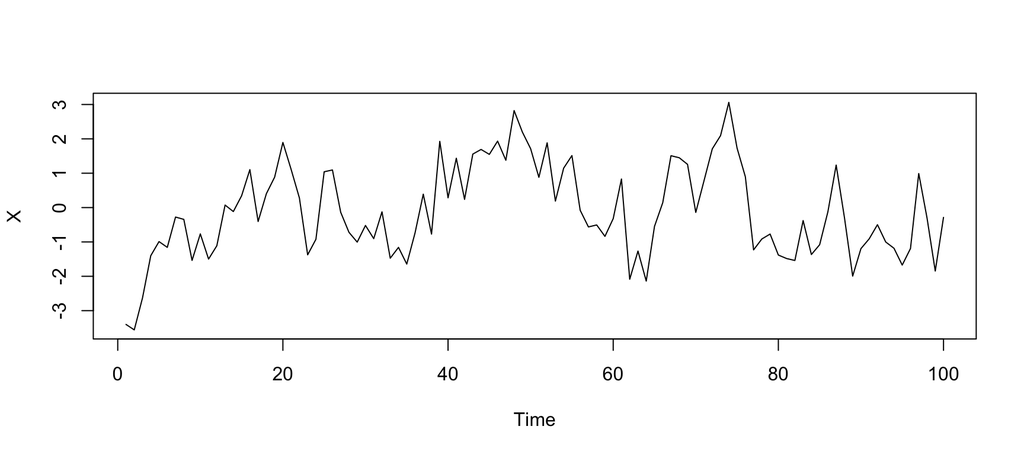

```r
  X <- arima.sim(list(ar = c(.6, .3) ), 100 ) # Simulate AR(2)

  plot(X)
```

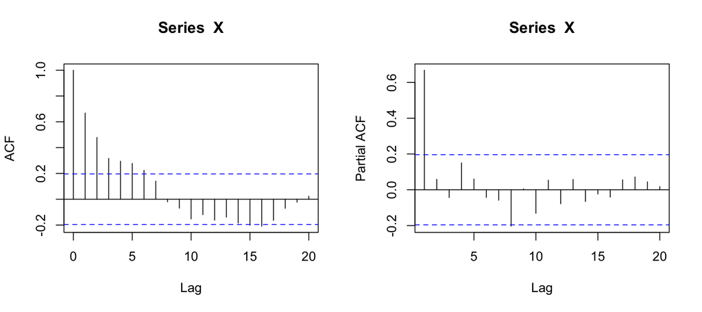

```r
  layout(matrix(1:2, 1, 2))   # 2 plot side by side
  acf(X)
  pacf(X)
```

### Example: PACF of Dowj log-difference

```r
  # read in daily Dow Jones data from my website
  D  <- read.csv("https://nmimoto.github.io//datasets/dowj.csv")
  D1 <- ts(D, start=c(1,1), freq=1)   # turn the data into TS object
  Y1 <- diff(log(D1))                 # Take log-difference log(X_{t}) - log(X_{t-1})
    Y <- Y1[-1]                         # remove the first observation because it's NA
  head(Y)
```

```
## [1] -0.0023516653  0.0011765240  0.0017170489  0.0008123111 -0.0034342555
## [6]  0.0009048955
```

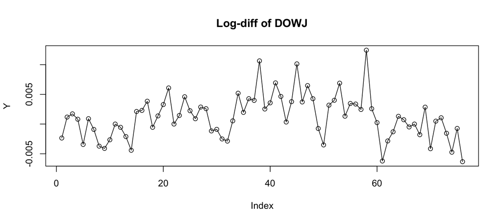

```r
  plot(Y, type='o', main="Log-diff of DOWJ")
```

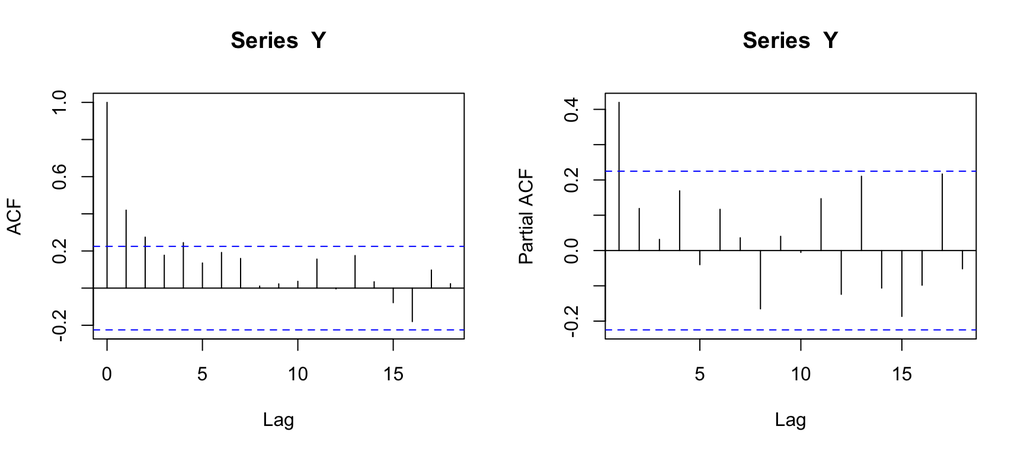

```r
  layout(matrix(1:2, 1, 2))           # make next two plot side by side (you don't have to do this)
  acf(Y)                              # Sample ACF
  pacf(Y)                             # Sample Partial ACF (see below)
```